# Model sensitivity analysis [benchmark data]

Martin R. Vasilev

May 18, 2016

## Mean Baseline Fixation Durations for All Studies [FFD]

| Prior on $\theta$ | Prior on $\tau$ | Posterior $\theta$ (SD) [95% CrI] | Posterior $\tau$ (SD) [95% CrI] |
| --- | --- | --- | --- |
| **Uniform(0, 800)** | **Uniform(0, 800)** | 247.23 (2.38) [242.54, 251.9] | 21.54 (1.81) [18.28, 25.42] |
| Normal(0, $100^2$) | Uniform(0, 800) | 247.1 (2.37) [242.43, 251.77] | 21.53 (1.8) [18.3, 25.33] |
| Uniform(0, 800) | Gamma(0.001, 0.001) | 247.23 (2.37) [242.6, 251.88] | 21.39 (1.77) [18.21, 25.16] |
| Normal(0, $100^2$) | Gamma(0.001, 0.001) | 247.07 (3.07) [242.49, 251.73] | 21.39 (1.78) [18.23, 25.14] |
| Uniform(0, 800) | Normal(0, $100^2$) I(0,) | 247.23 (2.38) [242.57, 251.91] | 21.53 (1.8) [18.3, 25.37] |
| Normal(0, $100^2$) | Normal(0, $100^2$) I(0,) | 247.1 (2.37) [242.4, 251.72] | 21.53 (1.8) [18.3, 25.38] |

*Note*: For Gamma distributions, the prior is on the precision (i.e. $1/\tau^2$). The priors in bold are the ones on which the results in the paper are based.

## Mean Baseline Fixation Durations for All Studies [SFD]

| Prior on $\theta$ | Prior on $\tau$ | Posterior $\theta$ (SD) [95% CrI] | Posterior $\tau$ (SD) [95% CrI] |
| --- | --- | --- | --- |
| **Uniform(0, 800)** | **Uniform(0, 800)** | 250.45 (3.82) [242.96, 257.93] | 23.89 (2.94) [18.89, 30.38] |
| Normal(0, $100^2$) | Uniform(0, 800) | 250.05 (3.8) [242.51, 257.45] | 23.87 (2.92) [18.85, 30.31] |
| Uniform(0, 800) | Gamma(0.001, 0.001) | 250.44 (3.74) [243.03, 257.82] | 23.52 (2.84) [18.69, 29.79] |
| Normal(0, $100^2$) | Gamma(0.001, 0.001) | 250.05 (4.25) [242.68, 257.42] | 23.55 (2.86) [18.69, 29.81] |
| Uniform(0, 800) | Normal(0, $100^2$) I(0,) | 250.4 (3.83) [242.83, 257.99] | 23.86 (2.91) [18.89, 30.32] |
| Normal(0, $100^2$) | Normal(0, $100^2$) I(0,) | 250.07 (3.82) [242.51, 257.59] | 23.86 (2.93) [18.86, 30.42] |

*Note*: For Gamma distributions, the prior is on the precision (i.e. $1/\tau^2$). The priors in bold are the ones on which the results in the paper are based.

## Mean Baseline Fixation Durations for All Studies [GD]

| Prior on $\theta$ | Prior on $\tau$ | Posterior $\theta$ (SD) [95% CrI] | Posterior $\tau$ (SD) [95% CrI] |
| --- | --- | --- | --- |
| **Uniform(0, 1000)** | **Uniform(0, 1000)** | 284.22 (3.77) [276.81, 291.71] | 35.89 (2.83) [30.76, 41.93] |
| Normal(0, $100^2$) | Uniform(0, 1000) | 283.82 (3.76) [276.49, 291.24] | 35.91 (2.83) [30.84, 41.97] |
| Uniform(0, 1000) | Gamma(0.001, 0.001) | 284.2 (3.77) [276.81, 291.62] | 35.69 (2.8) [30.66, 41.66] |
| Normal(0, $100^2$) | Gamma(0.001, 0.001) | 283.8 (4.4) [276.37, 291.23] | 35.7 (2.82) [30.69, 41.66] |
| Uniform(0, 1000) | Normal(0, $100^2$) I(0,) | 284.18 (3.78) [276.75, 291.59] | 35.89 (2.81) [30.84, 41.8] |
| Normal(0, $100^2$) | Normal(0, $100^2$) I(0,) | 283.8 (3.74) [276.53, 291.12] | 35.88 (2.83) [30.84, 41.88] |

*Note*: For Gamma distributions, the prior is on the precision (i.e. $1/\tau^2$). The priors in bold are the ones on which the results in the paper are based.

## Mean Baseline Fixation Durations for All Studies [TVT]

| Prior on $\theta$ | Prior on $\tau$ | Posterior $\theta$ (SD) [95% CrI] | Posterior $\tau$ (SD) [95% CrI] |
| --- | --- | --- | --- |
| **Uniform(0, 1000)** | **Uniform(0, 1000)** | 333.99 (9.99) [314.23, 353.7] | 51.48 (7.69) [38.88, 69] |
| Normal(0, $100^2$) | Uniform(0, 1000) | 330.72 (10.03) [310.46, 350.15] | 51.5 (7.78) [38.88, 69.24] |
| Uniform(0, 1000) | Gamma(0.001, 0.001) | 334.06 (9.79) [314.76, 353.44] | 50.34 (7.39) [38.3, 67.04] |
| Normal(0, $100^2$) | Gamma(0.001, 0.001) | 330.8 (10.09) [311.32, 349.72] | 50.33 (7.41) [38.16, 67.02] |
| Uniform(0, 1000) | Normal(0, $100^2$) I(0,) | 333.92 (9.99) [314.24, 353.86] | 51.12 (7.58) [38.74, 68.15] |
| Normal(0, $100^2$) | Normal(0, $100^2$) I(0,) | 330.61 (9.92) [310.44, 349.82] | 51.23 (7.59) [38.85, 68.55] |

*Note*: For Gamma distributions, the prior is on the precision (i.e. $1/\tau^2$). The priors in bold are the ones on which the results in the paper are based.

## Mean Baseline Fixation Durations for Alphabetical Studies [FFD]

| Prior on $\theta$ | Prior on $\tau$ | Posterior $\theta$ (SD) [95% CrI] | Posterior $\tau$ (SD) [95% CrI] |
| --- | --- | --- | --- |
| **Uniform(0, 800)** | **Uniform(0, 800)** | 246.25 (2.69) [240.97, 251.52] | 22.29 (2.05) [18.64, 26.65] |
| Normal(0, $100^2$) | Uniform(0, 800) | 246.07 (2.68) [240.85, 251.31] | 22.28 (2.03) [18.65, 26.62] |
| Uniform(0, 800) | Gamma(0.001, 0.001) | 246.24 (2.66) [241.07, 251.46] | 22.09 (2.01) [18.53, 26.39] |
| Normal(0, $100^2$) | Gamma(0.001, 0.001) | 246.06 (3.31) [240.86, 251.29] | 22.08 (2.01) [18.52, 26.42] |
| Uniform(0, 800) | Normal(0, $100^2$) I(0,) | 246.26 (2.68) [240.98, 251.5] | 22.24 (2.01) [18.69, 26.54] |
| Normal(0, $100^2$) | Normal(0, $100^2$) I(0,) | 246.07 (2.68) [240.78, 251.37] | 22.27 (2.02) [18.67, 26.62] |

*Note*: For Gamma distributions, the prior is on the precision (i.e. $1/\tau^2$). The priors in bold are the ones on which the results in the paper are based.

## Mean Baseline Fixation Durations for Alphabetical Studies [SFD]

| Prior on $\theta$ | Prior on $\tau$ | Posterior $\theta$ (SD) [95% CrI] | Posterior $\tau$ (SD) [95% CrI] |
| --- | --- | --- | --- |
| **Uniform(0, 800)** | **Uniform(0, 800)** | 248.86 (4.65) [239.63, 258.08] | 26.34 (3.57) [20.35, 34.35] |
| Normal(0, $100^2$) | Uniform(0, 800) | 248.31 (4.64) [239.15, 257.54] | 26.32 (3.6) [20.3, 34.43] |
| Uniform(0, 800) | Gamma(0.001, 0.001) | 248.9 (4.56) [239.87, 257.93] | 25.86 (3.47) [20.01, 33.57] |
| Normal(0, $100^2$) | Gamma(0.001, 0.001) | 248.32 (4.97) [239.32, 257.22] | 25.87 (3.5) [20.04, 33.75] |
| Uniform(0, 800) | Normal(0, $100^2$) I(0,) | 248.85 (4.64) [239.61, 258.01] | 26.32 (3.6) [20.28, 34.32] |
| Normal(0, $100^2$) | Normal(0, $100^2$) I(0,) | 248.33 (4.62) [239.18, 257.32] | 26.31 (3.57) [20.33, 34.29] |

*Note*: For Gamma distributions, the prior is on the precision (i.e. $1/\tau^2$). The priors in bold are the ones on which the results in the paper are based.

## Mean Baseline Fixation Durations for Alphabetical Studies [GD]

| Prior on $\theta$ | Prior on $\tau$ | Posterior $\theta$ (SD) [95% CrI] | Posterior $\tau$ (SD) [95% CrI] |
| --- | --- | --- | --- |
| **Uniform(0, 1000)** | **Uniform(0, 1000)** | 280.47 (3.53) [273.52, 287.44] | 30.05 (2.69) [25.26, 35.8] |
| Normal(0, $100^2$) | Uniform(0, 1000) | 280.15 (3.54) [273.22, 287.09] | 30.03 (2.67) [25.27, 35.75] |
| Uniform(0, 1000) | Gamma(0.001, 0.001) | 280.5 (3.52) [273.57, 287.37] | 29.81 (2.64) [25.12, 35.48] |
| Normal(0, $100^2$) | Gamma(0.001, 0.001) | 280.13 (4.16) [273.24, 287.04] | 29.79 (2.65) [25.09, 35.41] |
| Uniform(0, 1000) | Normal(0, $100^2$) I(0,) | 280.48 (3.54) [273.52, 287.49] | 30.03 (2.67) [25.31, 35.72] |
| Normal(0, $100^2$) | Normal(0, $100^2$) I(0,) | 280.12 (3.53) [273.16, 287.1] | 30.01 (2.67) [25.3, 35.68] |

*Note*: For Gamma distributions, the prior is on the precision (i.e. $1/\tau^2$). The priors in bold are the ones on which the results in the paper are based.

| Prior on $\theta$ | Prior on $\tau$ | Posterior $\theta$ (SD) [95% CrI] | Posterior $\tau$ (SD) [95% CrI] |
| --- | --- | --- | --- |
| **Uniform(0, 1000)** | **Uniform(0, 1000)** | 334 (9.94) [314.36, 353.62] | 51.44 (7.71) [38.85, 68.91] |
| Normal(0, $100^2$) | Uniform(0, 1000) | 330.75 (10.04) [310.52, 350.21] | 51.55 (7.73) [38.96, 69.1] |
| Uniform(0, 1000) | Gamma(0.001, 0.001) | 333.93 (9.77) [314.61, 353.09] | 50.37 (7.4) [38.21, 67.04] |
| Normal(0, $100^2$) | Gamma(0.001, 0.001) | 330.78 (10.16) [311.23, 349.99] | 50.42 (7.42) [38.36, 67.38] |
| Uniform(0, 1000) | Normal(0, $100^2$) I(0,) | 333.98 (9.91) [314.34, 353.44] | 51.12 (7.57) [38.78, 68.32] |
| Normal(0, $100^2$) | Normal(0, $100^2$) I(0,) | 330.74 (9.89) [311.18, 349.99] | 51.09 (7.56) [38.88, 68.31] |

*Note*: For Gamma distributions, the prior is on the precision (i.e. $1/\tau^2$). The priors in bold are the ones on which the results in the paper are based.

## Mean Baseline Fixation Durations for Chinese Studies [FFD]

| Prior on $\theta$ | Prior on $\tau$ | Posterior $\theta$ (SD) [95% CrI] | Posterior $\tau$ (SD) [95% CrI] |
| --- | --- | --- | --- |
| **Uniform(0, 800)** | **Uniform(0, 800)** | 252.34 (5.34) [241.62, 262.86] | 18.94 (4.68) [11.87, 29.86] |
| Normal(0, $100^2$) | Uniform(0, 800) | 251.6 (5.36) [240.79, 261.97] | 18.96 (4.71) [11.87, 30.03] |
| Uniform(0, 800) | Gamma(0.001, 0.001) | 252.35 (5.07) [242.17, 262.34] | 17.93 (4.29) [11.3, 27.9] |
| Normal(0, $100^2$) | Gamma(0.001, 0.001) | 251.68 (5.5) [241.35, 261.66] | 17.95 (4.32) [11.27, 28.1] |
| Uniform(0, 800) | Normal(0, $100^2$) I(0,) | 252.35 (5.27) [241.8, 262.75] | 18.89 (4.65) [11.74, 29.94] |
| Normal(0, $100^2$) | Normal(0, $100^2$) I(0,) | 251.63 (5.35) [240.77, 262.02] | 18.99 (4.7) [11.88, 30.3] |

*Note*: For Gamma distributions, the prior is on the precision (i.e. $1/\tau^2$). The priors in bold are the ones on which the results in the paper are based.

## Mean Baseline Fixation Durations for Chinese Studies [SFD]

| Prior on $\theta$ | Prior on $\tau$ | Posterior $\theta$ (SD) [95% CrI] | Posterior $\tau$ (SD) [95% CrI] |
| --- | --- | --- | --- |
| **Uniform(0, 800)** | **Uniform(0, 800)** | 256.79 (4.1) [248.85, 265.14] | 8.19 (4.92) [0.78, 19.92] |
| Normal(0, $100^2$) | Uniform(0, 800) | 256.39 (4.08) [248.16, 264.56] | 8.22 (4.9) [0.83, 20.03] |
| Uniform(0, 800) | Gamma(0.001, 0.001) | 256.51 (2.96) [250.74, 262.57] | 3.79 (4.07) [0.04, 13.58] |
| Normal(0, $100^2$) | Gamma(0.001, 0.001) | 256.31 (3.66) [250.4, 262.43] | 3.92 (4.11) [0.04, 13.96] |
| Uniform(0, 800) | Normal(0, $100^2$) I(0,) | 256.83 (4.07) [248.86, 265.14] | 8.21 (4.91) [0.82, 19.86] |
| Normal(0, $100^2$) | Normal(0, $100^2$) I(0,) | 256.37 (4.1) [248.1, 264.44] | 8.2 (5) [0.76, 19.84] |

*Note*: For Gamma distributions, the prior is on the precision (i.e. $1/\tau^2$). The priors in bold are the ones on which the results in the paper are based.

## Mean Baseline Fixation Durations for Chinese Studies [GD]

| Prior on $\theta$ | Prior on $\tau$ | Posterior $\theta$ (SD) [95% CrI] | Posterior $\tau$ (SD) [95% CrI] |
| --- | --- | --- | --- |
| **Uniform(0, 1000)** | **Uniform(0, 1000)** | 300.27 (14.02) [272.27, 328.2] | 57.76 (11.32) [40.24, 84.37] |
| Normal(0, $100^2$) | Uniform(0, 1000) | 294.41 (14.05) [265.1, 321.07] | 58.02 (11.55) [40.3, 84.95] |
| Uniform(0, 1000) | Gamma(0.001, 0.001) | 300.26 (13.45) [273.75, 327.11] | 55.65 (10.67) [39.24, 80.68] |
| Normal(0, $100^2$) | Gamma(0.001, 0.001) | 294.91 (13.87) [266.92, 321.08] | 55.96 (10.83) [39.44, 81.43] |
| Uniform(0, 1000) | Normal(0, $100^2$) I(0,) | 300.22 (13.8) [272.97, 327.64] | 56.91 (10.89) [39.96, 82.25] |
| Normal(0, $100^2$) | Normal(0, $100^2$) I(0,) | 294.68 (13.99) [265.93, 321.27] | 57.15 (11.05) [40.15, 82.96] |

*Note*: For Gamma distributions, the prior is on the precision (i.e. $1/\tau^2$). The priors in bold are the ones on which the results in the paper are based.

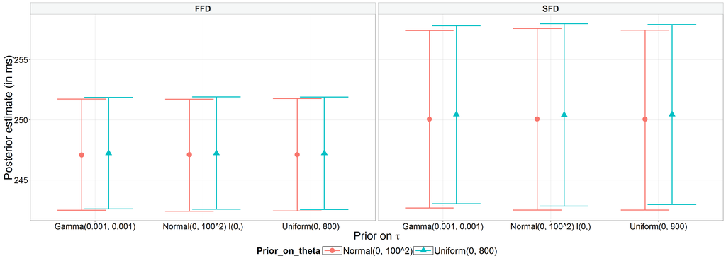

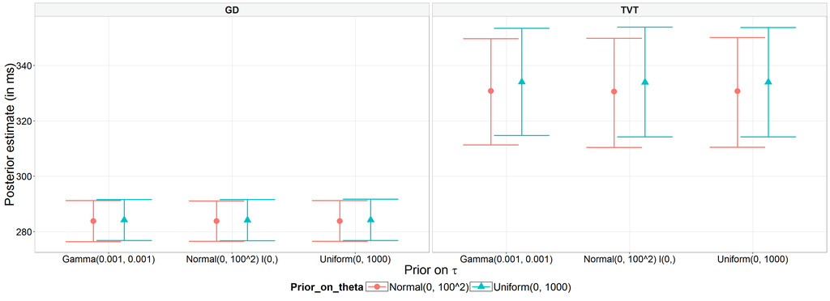